# Analyzing tRNA sequences and structures

Felix G.M. Ernst

2024-01-18

#### Abstract

Example of importing tRNAdb output as GRanges

#### Package

tRNA 1.20.1

# 1 Introduction

The `tRNA` package provides access to tRNA feature information for subsetting and visualization. Visualization functions are implemented to compare feature parameters of multiple tRNA sets and to correlate them to additional data.

As input the package expects a `GRanges` object with certain metadata columns. The following columns are required: `tRNA_length`, `tRNA_type`, `tRNA_anticodon`, `tRNA_seq`, `tRNA_str`, `tRNA_CCA.end`. The `tRNA_str` column must contain a valid dot bracket annotation. For more details please have a look at the vignette of the `Structstrings` package.

# 2 Loading tRNA information

To work with the `tRNA` package, tRNA information can be retrieved or loaded into a R session in a number of ways:

1. A `GRanges` object can be constructed manually containing the required colums mentioned above.
2. a tRNAscan result file can be loaded using the function `import.tRNAscanAsGRanges()` from the `tRNAscanImport` package
3. selected tRNA information can be retrieved using the function `import.tRNAdb()` from the `tRNAdbImport` package

For the examples in this vignette a number of predefined `GRanges` objects are loaded.

```r
library(tRNA)
library(Structstrings)
data("gr", package = "tRNA")
```

# 3 tRNA sequences and structures

To retrieve the sequences for individual tRNA structure elements the functions `gettRNAstructureGRanges` or `gettRNAstructureSeqs` can be used. Several optional arguments can be used to modify the result (See `?gettRNAstructureSeqs`).

```r
# just get the coordinates of the anticodonloop
gettRNAstructureGRanges(gr, structure = "anticodonLoop")
```

```
## $anticodonLoop
## IRanges object with 299 ranges and 0 metadata columns:
##           start       end     width
##       <integer> <integer> <integer>
##   TGG        31        37         7
##   TGC        32        38         7
##   CAA        31        37         7
##   AGA        31        37         7
##   TAA        31        37         7
##   ...       ...       ...       ...
##   CAT        32        38         7
##   GAA        31        37         7
##   TTA        31        37         7
##   TAC        32        38         7
##   CAT        32        38         7
```

```r
gettRNAstructureSeqs(gr, joinFeatures = TRUE, structure = "anticodonLoop")
```

```
## $anticodonLoop
## RNAStringSet object of length 299:
##       width seq                                             names
##   [1]     7 UUUGGGU                                         TGG
##   [2]     7 CUUGCAA                                         TGC
##   [3]     7 UUCAAGC                                         CAA
##   [4]     7 UUAGAAA                                         AGA
##   [5]     7 CUUAAGA                                         TAA
##   ...   ... ...
## [295]     7 CUCAUAA                                         CAT
## [296]     7 UUGAAGA                                         GAA
## [297]     7 UUUUAGU                                         TTA
## [298]     7 UUUACAC                                         TAC
## [299]     7 GUCAUGA                                         CAT
```

In addition, the sequences can be returned already joined to get a fully blank padded set of sequences. The boundaries of the individual structures is returned as metadata of the `RNAStringSet` object.

```r
seqs <- gettRNAstructureSeqs(gr[1L:10L], joinCompletely = TRUE)
seqs
```

```
## RNAStringSet object of length 10:
##      width seq
##  [1]    85 GGGCGUGUGGUC-UAGU-GGUAU-GAUUCUCGC...------GCCUGGGUUCAAUUCCCAGCUCGCCCC
##  [2]    85 GGGCACAUGGCGCAGUU-GGU-AGCGCGCUUCC...------GCAUCGGUUCGAUUCCGGUUGCGUCCA
##  [3]    85 GGUUGUUUGGCC-GAGC-GGUAA-GGCGCCUGA...AA-GAUGCAAGAGUUCGAAUCUCUUAGCAACCA
##  [4]    85 GGCAACUUGGCC-GAGU-GGUAA-GGCGAAAGA...U-GCCCGCGCAGGUUCGAGUCCUGCAGUUGUCG
##  [5]    85 GGAGGGUUGGCC-GAGU-GGUAA-GGCGGCAGA...UUGUCCGCGCGAGUUCGAACCUCGCAUCCUUCA
##  [6]    85 GCGGAUUUAGCUCAGUU-GGG-AGAGCGCCAGA...------GCCUGUGUUCGAUCCACAGAAUUCGCA
##  [7]    85 GGUCUCUUGGCC-CAGUUGGUAA-GGCACCGUG...------ACAGCGGUUCGAUCCCGCUAGAGACCA
##  [8]    85 GCGCAAGUGGUUUAGU--GGU-AAAAUCCAACG...-------CCCCGGUUCGAUUCCGGGCUUGCGCA
##  [9]    85 GGCAACUUGGCC-GAGU-GGUAA-GGCGAAAGA...U-GCCCGCGCAGGUUCGAGUCCUGCAGUUGUCG
## [10]    85 GCUUCUAUGGCC-AAGUUGGUAA-GGCGCCACA...------ACAUCGGUUCAAAUCCGAUUGGAAGCA
```

```r
# getting the tRNA structure boundaries
metadata(seqs)[["tRNA_structures"]]
```

```
## IRanges object with 15 ranges and 0 metadata columns:
##                           start       end     width
##                       <integer> <integer> <integer>
##   acceptorStem.prime5         1         7         7
##               Dprime5         8         9         2
##          DStem.prime5        10        13         4
##                 Dloop        14        23        10
##          DStem.prime3        24        27         4
##                   ...       ...       ...       ...
##          TStem.prime5        61        65         5
##                 Tloop        66        72         7
##          TStem.prime3        73        77         5
##   acceptorStem.prime3        78        84         7
##         discriminator        85        85         1
```

Be aware, that `gettRNAstructureGRanges` and `gettRNAstructureSeqs` might not be working as expected, if the tRNA sequences in questions are armless or deviate drastically from the canonical tRNA model. The functions in the `tRNA` packages were thouroughly tested using human mitochondrial tRNA and other tRNAs missing certain features. However, for fringe cases results may differ. If you encounter such a case, please report it with an example.

# 4 Subsetting tRNA sequences

Structure information of the tRNA can be queried for subsetting using several functions. For the following examples the functions `hasAccpeptorStem` and `hasDloop` are used.

```r
gr[hasAcceptorStem(gr, unpaired = TRUE)]
# mismatches and bulged are subsets of unpaired
gr[hasAcceptorStem(gr, mismatches = TRUE)]
gr[hasAcceptorStem(gr, bulged = TRUE)]
# combination of different structure parameters
gr[hasAcceptorStem(gr, mismatches = TRUE) &
     hasDloop(gr, length = 8L)]
```

Please have a look at the man page `?hasAccpeptorStem` for all available subsetting functions.

# 5 Visualization

To get an overview of tRNA features and compare different datasets, the function `gettRNAFeaturePlots` is used. It accepts a named `GRangesList` as input. Internally it will calculate a list of features values based on the functions mentioned above and the data contained in the mcols of the `GRanges` objects.

```r
# load tRNA data for E. coli and H. sapiens
data("gr_eco", package = "tRNA")
data("gr_human", package = "tRNA")

# get summary plots
grl <- GRangesList(Sce = gr,
                   Hsa = gr_human,
                   Eco = gr_eco)
plots <- gettRNAFeaturePlots(grl)
```

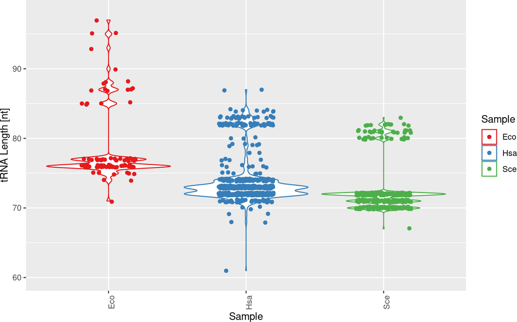

Figure 1: tRNA length

```r
plots$length
```

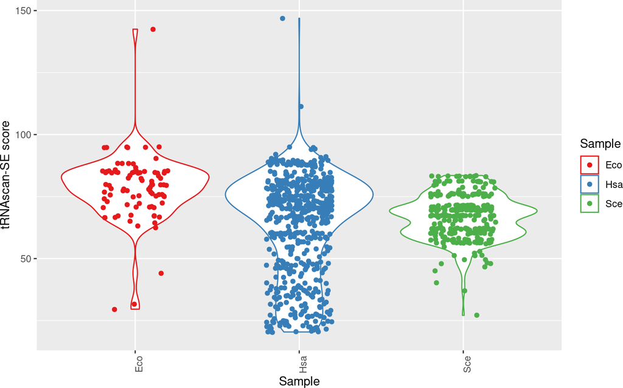

Figure 2: tRNAscan-SE scores

```r
plots$tRNAscan_score
```

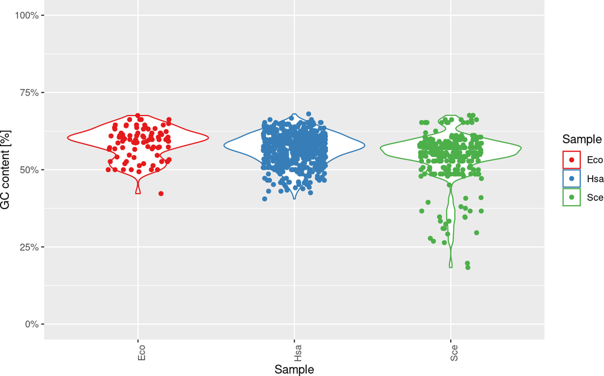

Figure 3: tRNA GC content

```r
plots$gc
```

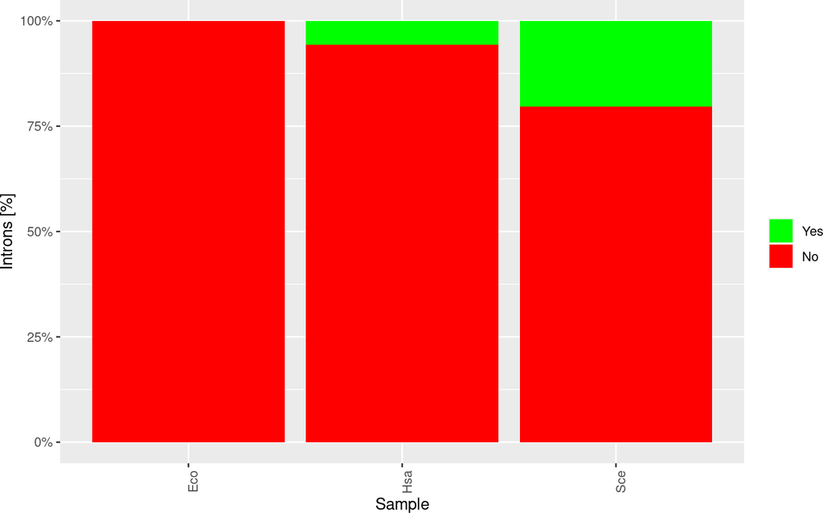

Figure 4: tRNAs with introns

```r
plots$tRNAscan_intron
```

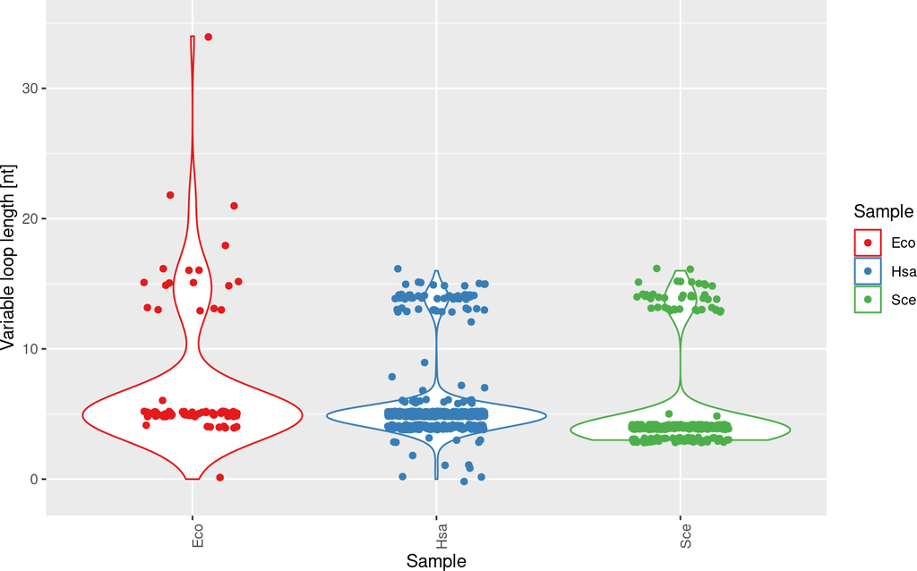

Figure 5: Length of the variable loop

```r
plots$variableLoop_length
```

To access the results without generating plots, use the function `gettRNASummary`.

To check whether features correlate with additional scores, optional arguments can be added to `gettRNAFeaturePlots` or used from the `score` column of the `GRanges` objects. For the first case a list of scores with the same dimensions as the `GRangesList` object has to be provided as the argument `scores`. For the latter case, just set the argument `plotScore = TRUE`.

```r
# score column will be used
plots <- gettRNAFeaturePlots(grl, plotScores = TRUE)
```

```r
plots <- gettRNAFeaturePlots(grl,
                             scores = list(runif(length(grl[[1L]]),0L,100L),
                                           runif(length(grl[[2L]]),0L,100L),
                                           runif(length(grl[[3L]]),0L,100L)))
```

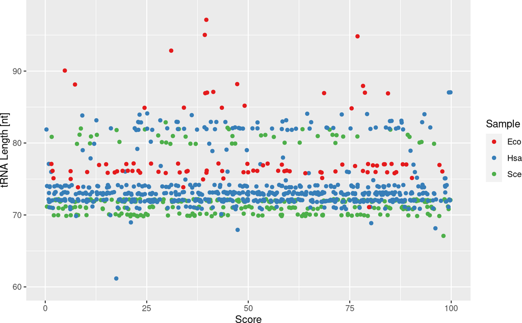

Figure 6: tRNA length and score correlation

```r
plots$length
```

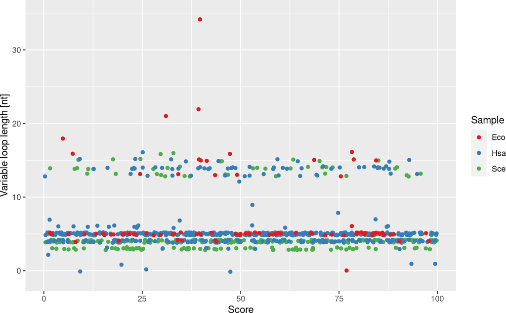

Figure 7: variable loop length and score correlation

```r
plots$variableLoop_length
```

Since all plots returned by the functions mentioned above are `ggplot2` objects, they can be modified manually and changed to suit your needs.

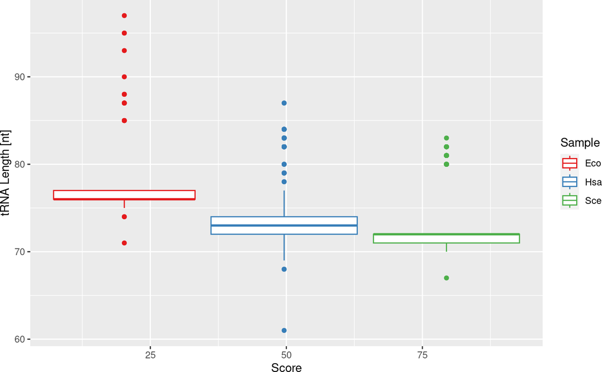

Figure 8: Customized plot switching out the point and violin plot into a boxplot

```r
plots$length$layers <- plots$length$layers[c(-1L,-2L)]
plots$length + ggplot2::geom_boxplot()
```

In addition, the data of the plots can be accessed directly.

```r
head(plots$length$data)
```

|  | id | value | score |
| --- | --- | --- | --- |
| 1 | Sce | 71 | 99.192907 |
| 2 | Sce | 72 | 88.552020 |
| 3 | Sce | 80 | 45.993326 |
| 4 | Sce | 81 | 89.286213 |
| 5 | Sce | 82 | 8.772107 |
| 6 | Sce | 72 | 18.774776 |

# 6 Options

The colours of the plots can be customized directly on creation with the following options.

```r
options("tRNA_colour_palette")
```

```
## $tRNA_colour_palette
## [1] "Set1"
```

```r
options("tRNA_colour_yes")
```

```
## $tRNA_colour_yes
## [1] "green"
```

```r
options("tRNA_colour_no")
```

```
## $tRNA_colour_no
## [1] "red"
```

# 7 Dot bracket annotation

To retrieve detailed information on the base pairing the function `gettRNABasePairing()` is used. Internally this will construct a `DotBracketStringSet` from the `tRNA_str` column, if this column does not already contain a `DotBracketStringSet`. It is then passed on to the `Structstrings::getBasePairing` function.

A valid DotBracket annotation is expected to contain only pairs of `<>{}[]()` and the `.` character (Please note the orientation. For `<>` the orientation is variable, since the tRNAscan files use the `><` annotation by default. However upon creation of a `DotBracketStringSet` this annotation will be converted).

```r
head(gettRNABasePairing(gr)[[1L]])
```

```
## DotBracketDataFrame with 6 rows and 4 columns
##         pos   forward   reverse   character
##   <integer> <integer> <integer> <character>
## 1         1         1        70           <
## 2         2         2        69           <
## 3         3         3        68           <
## 4         4         4        67           <
## 5         5         5        66           <
## 6         6         0         0           .
```

```r
head(getBasePairing(gr[1L]$tRNA_str)[[1L]])
```

```
## DotBracketDataFrame with 6 rows and 4 columns
##         pos   forward   reverse   character
##   <integer> <integer> <integer> <character>
## 1         1         1        70           <
## 2         2         2        69           <
## 3         3         3        68           <
## 4         4         4        67           <
## 5         5         5        66           <
## 6         6         0         0           .
```

The loop ids for the structure elements can be retrieved with the `gettRNALoopIDs()` function, which relies on the `Structstrings::getLoopIndices` function. (For more details, please have a look at the `?getLoopIndices`)

```r
gettRNALoopIDs(gr)[[1L]]
```

```
##  [1]  1  2  3  4  5  5  6  6  6  7  8  9  9  9  9  9  9  9  9  9  9  9  8  7  6
## [26] 10 11 12 13 14 14 14 14 14 14 14 14 14 13 12 11 10  6  6  6  6 15 16 17 18
## [51] 19 19 19 19 19 19 19 19 19 18 17 16 15  6  5  5  4  3  2  1  0
```

```r
getLoopIndices(gr[1L]$tRNA_str)
```

```
## LoopIndexList of length 1
## [[""]] 1 2 3 4 5 5 6 6 6 7 8 9 9 9 9 9 ... 19 19 19 18 17 16 15 6 5 5 4 3 2 1 0
```